# Rural vs Urban Regression

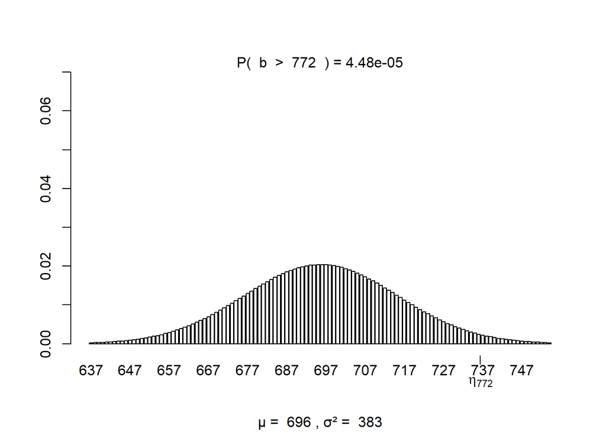

```
## numeric(0)
```

```r
#If sampled, chances are Half of size will had not graduated within 4 years
1-visualize.binom(stat = 772, size = 1546, prob = 0.45, section = "upper", strict = TRUE)
```

*4 Year plan for Entry Fall 2015

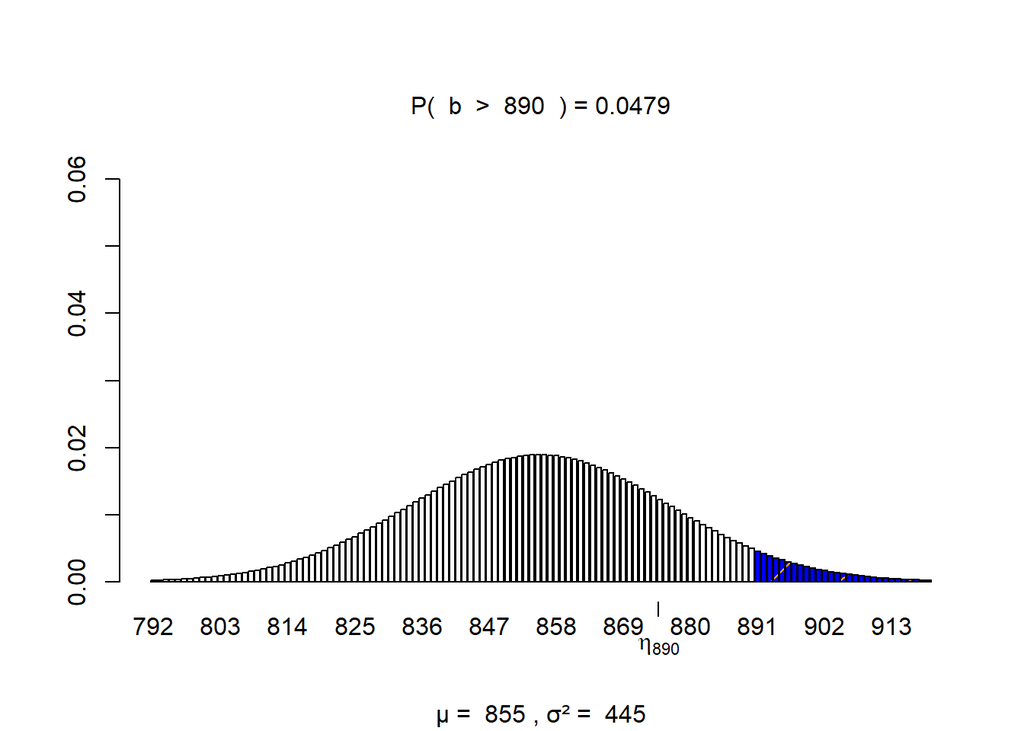

```
## numeric(0)
```

```r
#If sampled, chances are less than half of size will had graduate within 4 years
1-visualize.binom(stat = 890, size = 1782, prob = 0.48, section = "upper", strict = TRUE)
```

*4 Year plan for Entry Fall 2016

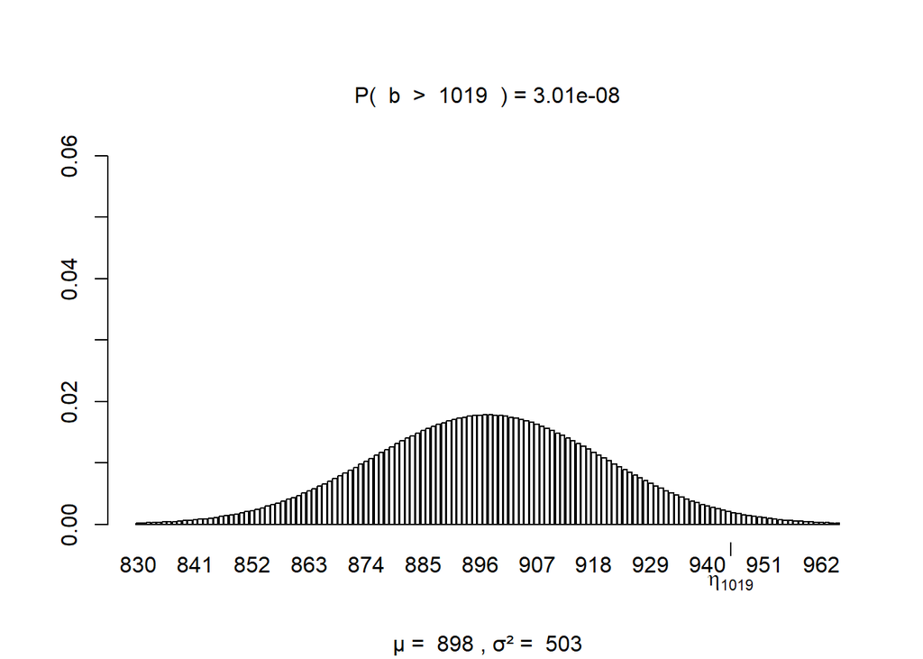

```
## numeric(0)
```

```r
#If sampled, chances are Half of size will not had graduated within 4 years
1-visualize.binom(stat = 1019, size = 2040, prob = 0.44, section = "upper", strict = TRUE)
```

*4 Year plan for Entry Fall 2017

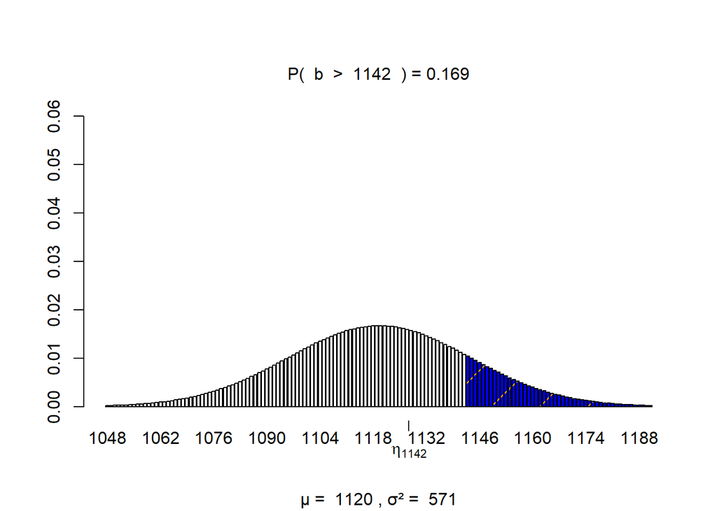

```
## numeric(0)
```

```r
#If sampled, little under a half of size would had graduated within 4 years
1-visualize.binom(stat = 1142, size = 2285, prob = 0.49, section = "upper", strict = TRUE)
```

*4 Year plan for Entry Fall 2018

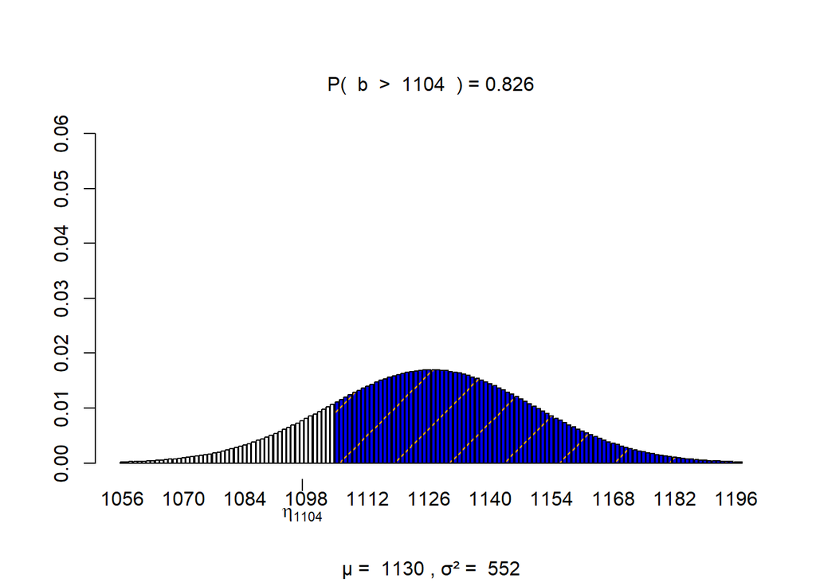

```
## numeric(0)
```

```r
##If sampled, most of the Half will had graduated within 4 years
1-visualize.binom(stat = 1104, size = 2209, prob = 0.51, section = "upper", strict = TRUE)
```

##Probability Distribution UCLA

*4 Year plan for Entry Fall 2005

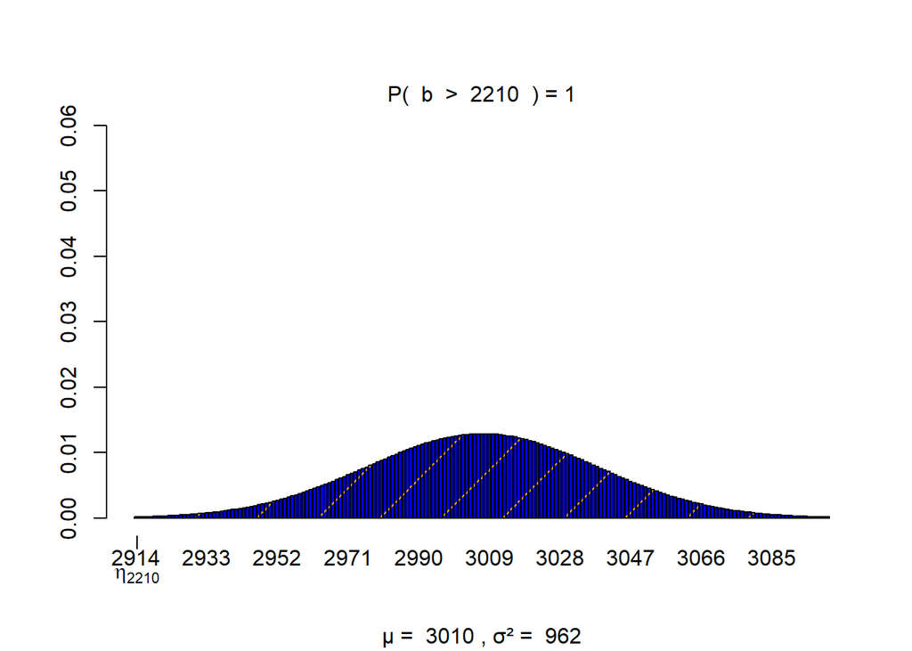

```
## numeric(0)
```

```r
#If sampled, chances are Half of size will had graduate within 4 years
1-visualize.binom(stat = 2210, size = 4422, prob = 0.68, section = "upper", strict = TRUE)
```

*4 Year plan for Entry Fall 2006

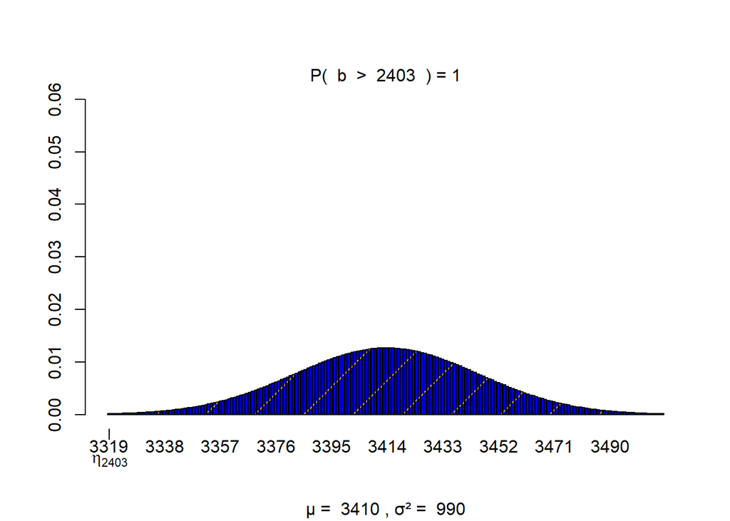

```
## numeric(0)
```

```r
#If sampled, chances are Half of size will had graduate within 4 years
1-visualize.binom(stat = 2403, size = 4808, prob = 0.71, section = "upper", strict = TRUE)
```

*4 Year plan for Entry Fall 2007

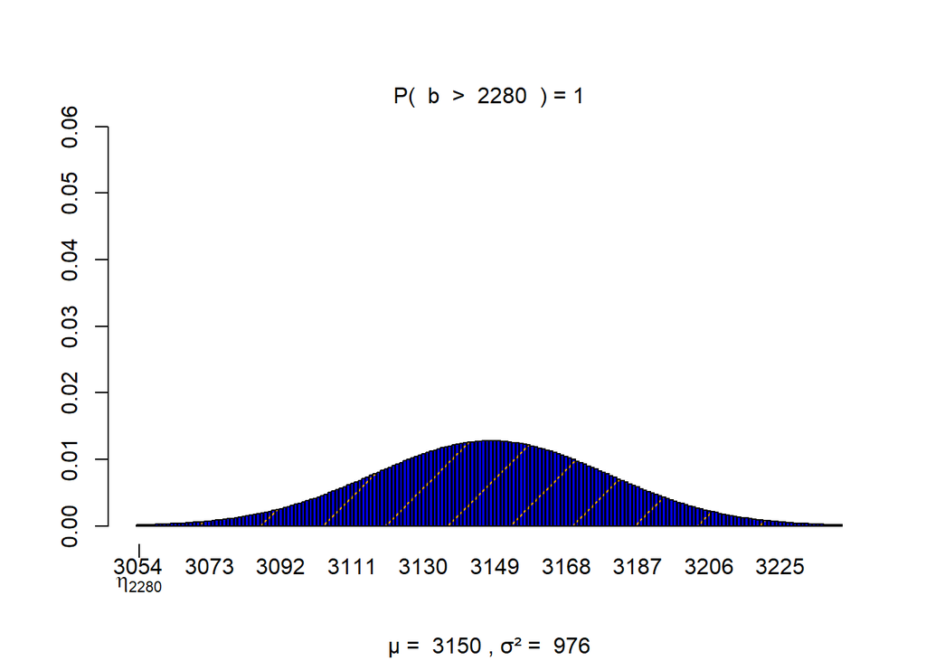

```
## numeric(0)
```

```r
#If sampled, chances are Half of size will had graduate within 4 years
1-visualize.binom(stat = 2280, size = 4562, prob = 0.69, section = "upper", strict = TRUE)
```

*4 Year plan for Entry Fall 2008

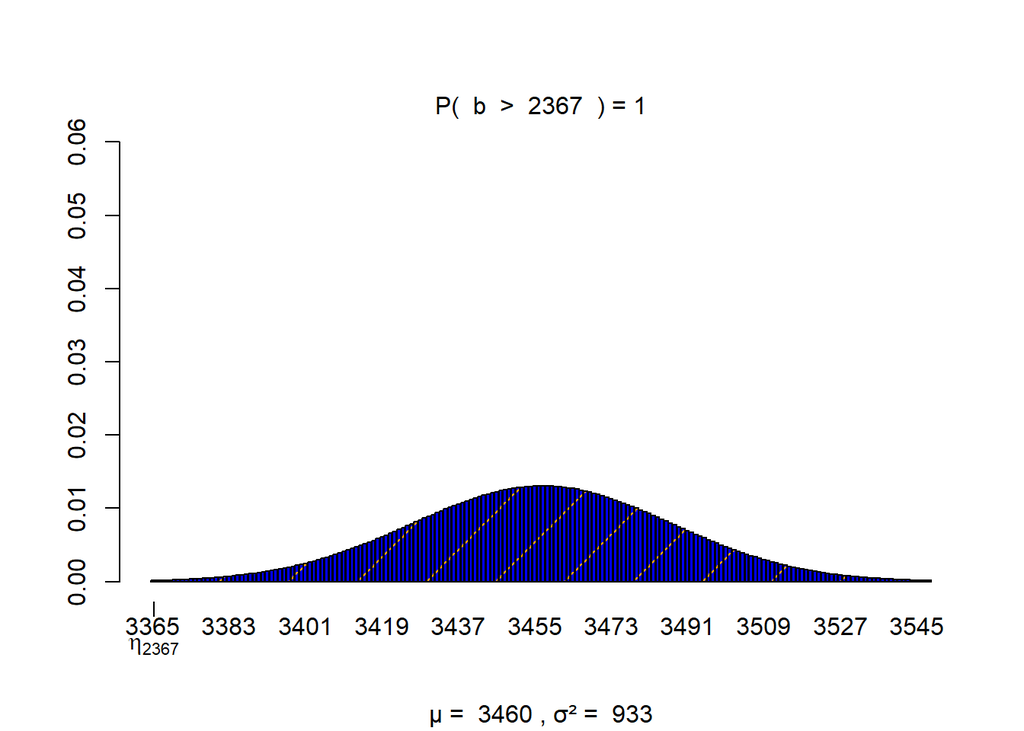

```
## numeric(0)
```

```r
#If sampled, chances are Half of size will had graduate within 4 years
1-visualize.binom(stat = 2367, size = 4735, prob = 0.73, section = "upper", strict = TRUE)
```

*4 Year plan for Entry Fall 2009

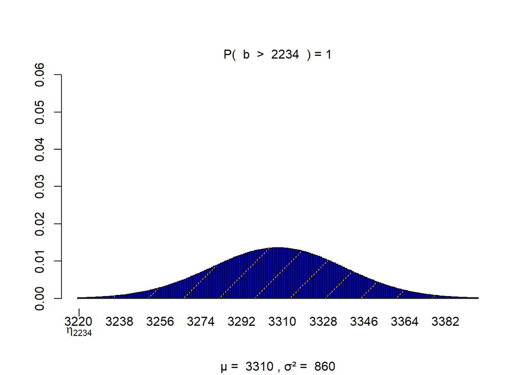

```
## numeric(0)
```

```r
#If sampled, chances are Half of size will had graduate within 4 years
1-visualize.binom(stat = 2234, size = 4470, prob = 0.74, section = "upper", strict = TRUE)
```

*4 Year plan for Entry Fall 2010

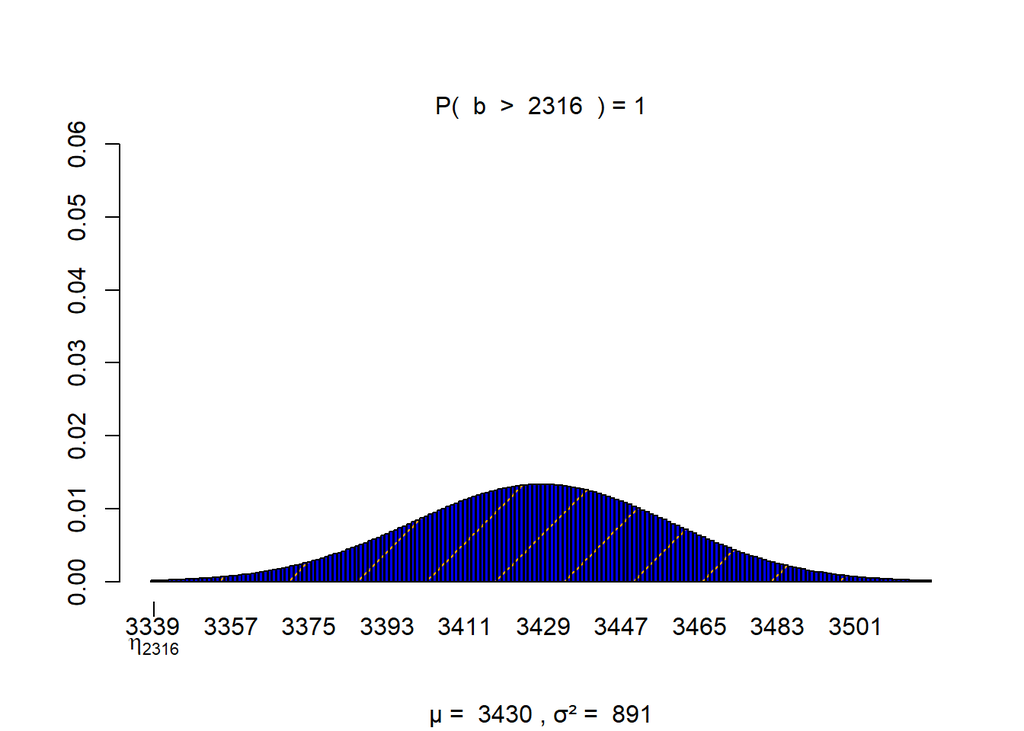

```
## numeric(0)
```

```r
#If sampled, chances are Half of size will had graduate within 4 years
1-visualize.binom(stat = 2316, size = 4633, prob = 0.74, section = "upper", strict = TRUE)
```

*4 Year plan for Entry Fall 2011

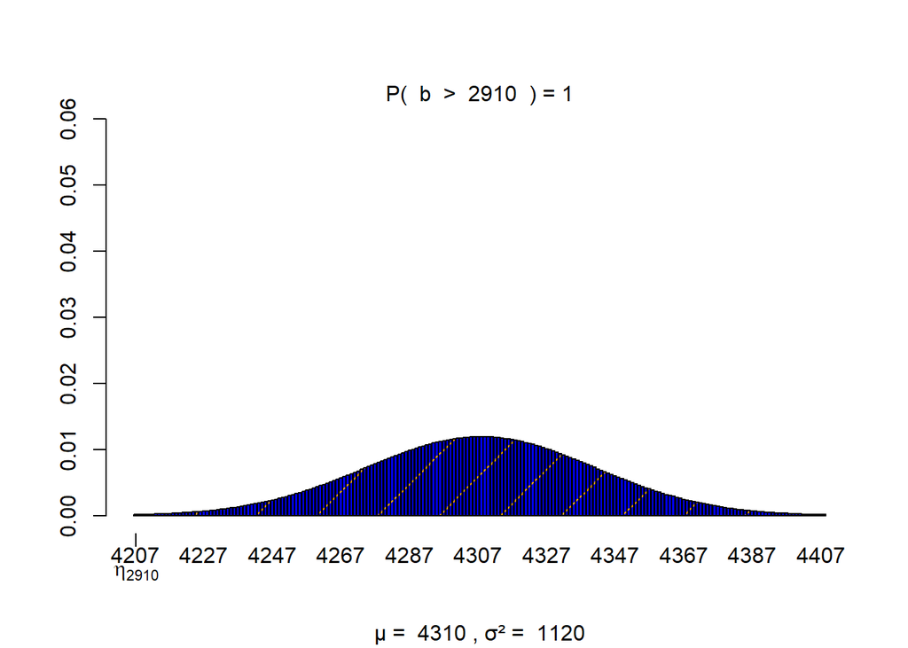

```
## numeric(0)
```

```r
#If sampled, chances are Half of size will had graduate within 4 years
1-visualize.binom(stat = 2910, size = 5821, prob = 0.74, section = "upper", strict = TRUE)
```

*4 Year plan for Entry Fall 2012

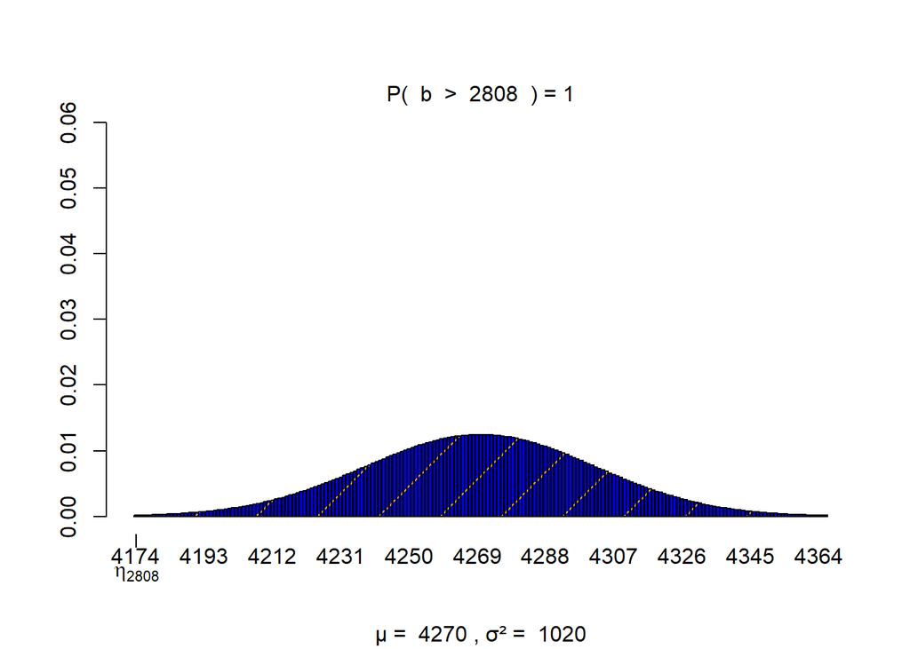

```
## numeric(0)
```

```r
#If sampled, chances are Half of size will had graduate within 4 years
1-visualize.binom(stat = 2808, size = 5618, prob = 0.76, section = "upper", strict = TRUE)
```

*4 Year plan for Entry Fall 2013

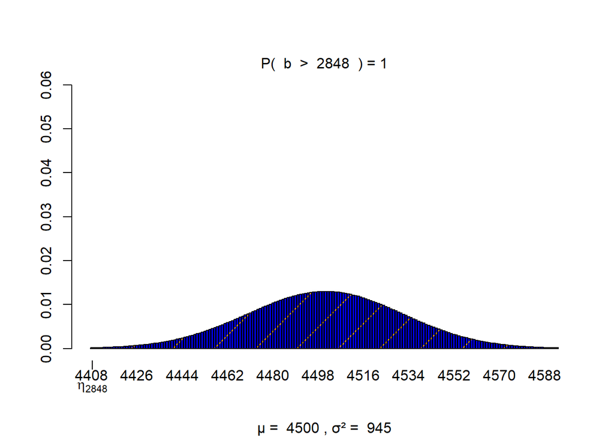

```
## numeric(0)
```

```r
#If sampled, chances are Half of size will had graduate within 4 years
1-visualize.binom(stat = 2848, size = 5697, prob = 0.79, section = "upper", strict = TRUE)
```

*4 Year plan for Entry Fall 2014

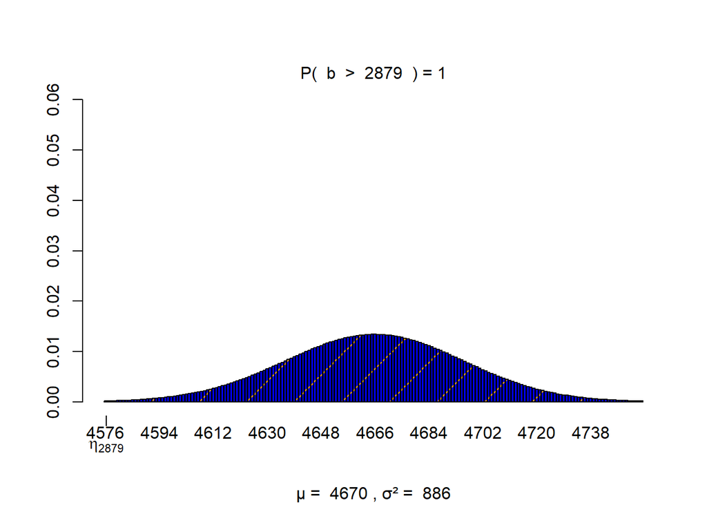

```
## numeric(0)
```

```r
#If sampled, chances are Half of size will had graduate within 4 years
1-visualize.binom(stat = 2879, size = 5760, prob = 0.81, section = "upper", strict = TRUE)
```

*4 Year plan for Entry Fall 2015

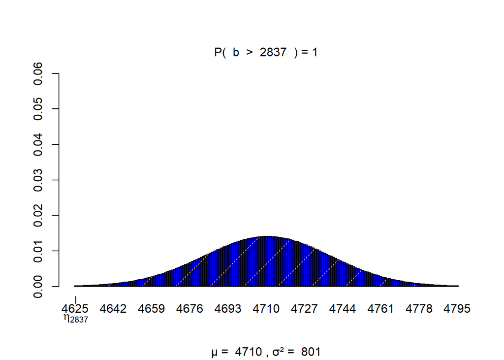

```
## numeric(0)
```

```r
#If sampled, chances are Half of size will had graduate within 4 years
1-visualize.binom(stat = 2837, size = 5675, prob = 0.83, section = "upper", strict = TRUE)
```

*4 Year plan for Entry Fall 2016

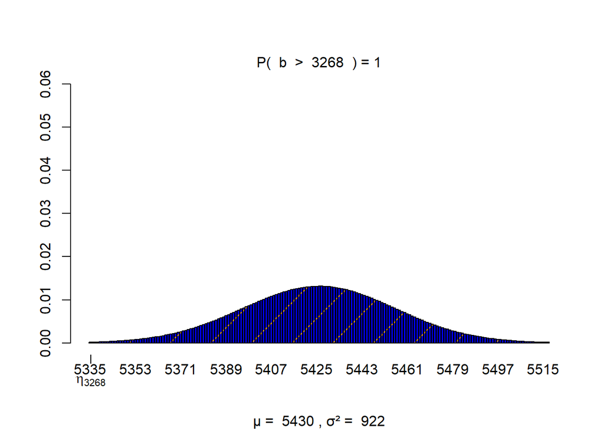

```
## numeric(0)
```

```r
#If sampled, chances are Half of size will had graduate within 4 years
1-visualize.binom(stat = 3268, size = 6537, prob = 0.83, section = "upper", strict = TRUE)
```

*4 Year plan for Entry Fall 2017

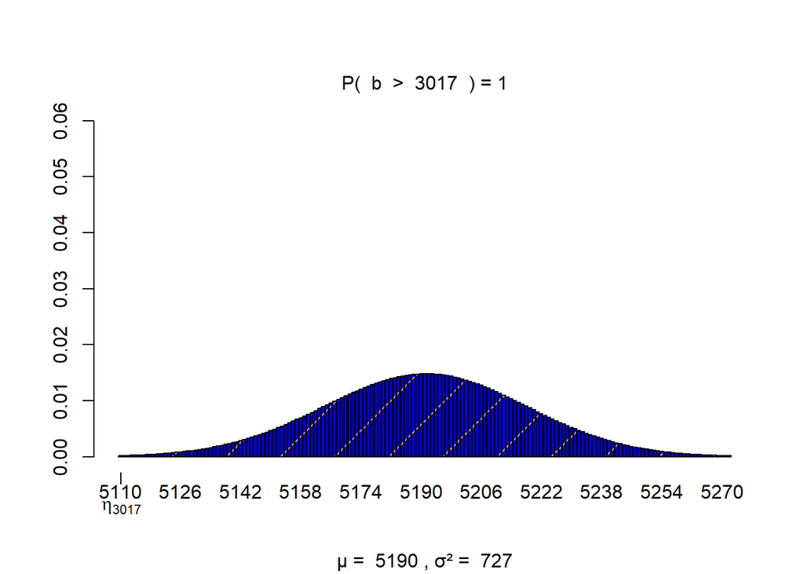

```
## numeric(0)
```

```r
#If sampled, chances are Half of size will had graduate within 4 years
1-visualize.binom(stat = 3017, size = 6036, prob = 0.86, section = "upper", strict = TRUE)
```

*4 Year plan for Entry Fall 2018

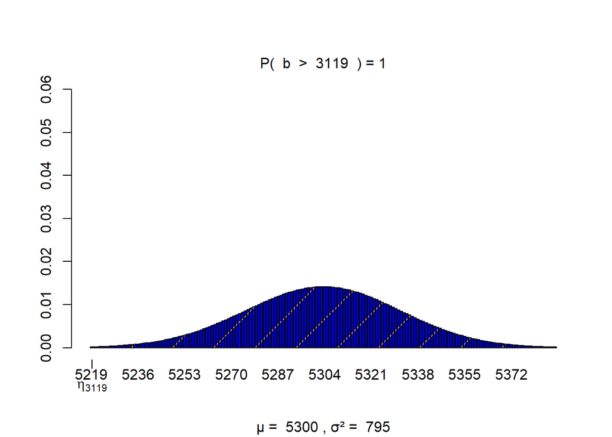

```
## numeric(0)
```

```r
#If sampled, chances are Half of size will had graduate within 4 years
1-visualize.binom(stat = 3119, size = 6239, prob = 0.85, section = "upper", strict = TRUE)
```

#Regression Modeling

```r
#Utilized correlation tests in the method of spearmman to get correlation score between Fall Size to Graduation Rates
MIX_2.1 <-cor.test(UCM_Regression$'3rd Year Graduation Rate', UCM_Regression$'Size',  method = "spearman")
MIX_2.2 <-cor.test(UCM_Regression$'4th Year Graduation Rate', UCM_Regression$'Size',  method = "spearman")
MIX_2.3 <-cor.test(UCM_Regression$'5th Year Graduation Rate', UCM_Regression$'Size',  method = "spearman")
MIX_2.4 <-cor.test(UCM_Regression$'6th Year Graduation Rate', UCM_Regression$'Size',  method = "spearman")
MIX_2.5 <-cor.test(UCLA_Regression$'3rd Year Graduation Rate', UCLA_Regression$'Size',  method = "spearman")
MIX_2.6 <-cor.test(UCLA_Regression$'4th Year Graduation Rate', UCLA_Regression$'Size',  method = "spearman")
MIX_2.7 <-cor.test(UCLA_Regression$'5th Year Graduation Rate', UCLA_Regression$'Size',  method = "spearman")
MIX_2.8 <-cor.test(UCLA_Regression$'6th Year Graduation Rate', UCLA_Regression$'Size',  method = "spearman")
```

*UCM linear regresssion

```r
sp <- UCM_Regression$'Size'
rp <- UCM_Regression$'4th Year Graduation Rate'
UCM_Regression1 <- lm(sp ~ rp, data = UCM_Regression)
moderndive::get_regression_table(UCM_Regression1)
```

```
## # A tibble: 2 × 7
##   term      estimate std_error statistic p_value lower_ci upper_ci
##   <chr>        <dbl>     <dbl>     <dbl>   <dbl>    <dbl>    <dbl>
## 1 intercept   -1356.      372.     -3.65   0.003   -2166.    -547.
## 2 rp           6989.      927.      7.54   0        4970.    9008.
```

$$\hat{y} = -1356.133 + 6989.106*4th Year
Graduation Rate$$

```r
predict(UCM_Regression1, newdata = data.frame('4th Year Graduation Rate' = 0.80))
```

```
##         1         2         3         4         5         6         7         8
##  950.2718  740.5986  530.9255 1020.1628 1229.8360 1299.7271  950.2718 1299.7271
##         9        10        11        12        13        14        15        16
## 1788.9644 1788.9644 1998.6376 1719.0734 2068.5287 2208.3108        NA        NA
##        17        18
##        NA        NA
```

*UCLA Linear regresssion

```r
sp1 <- UCLA_Regression$'Size'
rp1 <- UCLA_Regression$'4th Year Graduation Rate'
UCLA_Regression1 <- lm(sp1 ~ rp1, data = UCLA_Regression)
moderndive::get_regression_table(UCLA_Regression1)
```

```
## # A tibble: 2 × 7
##   term      estimate std_error statistic p_value lower_ci upper_ci
##   <chr>        <dbl>     <dbl>     <dbl>   <dbl>    <dbl>    <dbl>
## 1 intercept   -2924.     1208.     -2.42   0.032   -5556.    -292.
## 2 rp1         10760.     1565.      6.88   0        7351.   14170.
```

$$\hat{y} = -2923.781 + 10760.490*4th Year
Graduation Rate$$

```r
predict(UCLA_Regression1, newdata = data.frame('4th Year Graduation Rate' = 0.80))
```

```
##        1        2        3        4        5        6        7        8
## 4356.948 4721.359 4510.911 4911.946 5008.168 5042.651 5115.623 5337.165
##        9       10       11       12       13       14       15       16
## 5630.591 5772.413 5965.237 6154.405 6282.178 6203.405       NA       NA
##       17       18
##       NA       NA
```

#Hypothesis Testing

```r
# Size~4th Year Graduation Rate Correlation
# Utilized rnorm and t.test to draw p-values in relations bewetween the two variables.
```

```r
UCM_Regression |>
  summarize(xbar = mean(`Size`, na.rm = TRUE),
            median = median(`Size`, na.rm = TRUE),
            s = sd(`Size`, na.rm = TRUE))
```

```
## # A tibble: 1 × 3
##    xbar median     s
##   <dbl>  <dbl> <dbl>
## 1 1578.   1598  622.
```

*UCM Size ~ 4th Graduation Rate

```r
Test1.1 <- c(rnorm(1000, mean = 1578.22, sd = 622.0434))
Test1.2 <- c(rnorm(1000, mean = 0.3943, sd = 0.0758))
t.test(Test1.1, Test1.2, paired = TRUE)
```

```
##
##  Paired t-test
##
## data:  Test1.1 and Test1.2
## t = 82.834, df = 999, p-value < 2.2e-16
## alternative hypothesis: true mean difference is not equal to 0
## 95 percent confidence interval:
##  1563.995 1639.895
## sample estimates:
## mean difference
##        1601.945
```

```r
UCLA_Regression |>
  summarize(xbar = mean(`Size`, na.rm = TRUE),
            median = median(`Size`, na.rm = TRUE),
            s = sd(`Size`, na.rm = TRUE))
```

```
## # A tibble: 1 × 3
##    xbar median     s
##   <dbl>  <dbl> <dbl>
## 1 5575.  5728.  768.
```

*UCLA Size ~ 4th Graduation Rate

```r
Test2.1 <- c(rnorm(1000, mean = 5575.444, sd = 768.0545))
Test2.2 <- c(rnorm(1000, mean = 0.7697, sd = 0.06))
t.test(Test2.1, Test2.2, paired = TRUE)
```

```
##
##  Paired t-test
##
## data:  Test2.1 and Test2.2
## t = 232.16, df = 999, p-value < 2.2e-16
## alternative hypothesis: true mean difference is not equal to 0
## 95 percent confidence interval:
##  5522.918 5617.078
## sample estimates:
## mean difference
##        5569.998
```